# Exploring the BRFSS data

## Setup

### Load packages

```r
library(ggplot2)
library(dplyr)
library(scales)
```

### Load data

```r
load("brfss2013.RData")
```

## Part 1: Data

The data has been collected through landline telephonic interviews as well as cellular telephonic interviews. Their main objective is to collect uniform data that is state specific and they take into account behavioural risk factors of non-institutionalized adult population.It collects the data from all 50 states and terrotories. As the interviews are conducted on a randomly selected member of a family this shows that they use stratified sampling so this means that they can only make assosications from the data collected and not imply causation as all the data that is collected is observational and not obtained from a study.

## Part 2: Research questions

**Research quesion 1:** Is there any association between hours of sleep and mental health?

I wanted to ask this question as i tend to sleep less that 8 hours on a daily basis and wanted to see if there was any relation between mental health and the number of hours one sleeps.

**Research quesion 2:** How many hours per week one works compared to income range and how it affects ones satisfaction from life?

**Research quesion 3:** Is there any association between income group and height of a person?

When i was a kid i always wanted to be really tall. I thought what would the other benefits of being really tall be. Hence this question.

## Part 3: Exploratory data analysis

**Research quesion 1:**

First lets see out of all the people how many number of days are they the most mentally distrubed or the number of days their mental health is not good.

```r
brfss2013 %>%
  group_by(menthlth) %>%
  summarise(count=n()) %>%
  arrange(desc(count))
```

```
## # A tibble: 34 x 2
##    menthlth  count
##       <int>  <int>
##  1        0 334461
##  2       30  25521
##  3        2  23520
##  4        5  16654
##  5        1  15206
##  6        3  13593
##  7       10  11917
##  8       15  10910
##  9       NA   8627
## 10        4   6660
## # ... with 24 more rows
```

As we can see here that almost 68% of people have 0 mentally disturbing days. Although coming in second is the maximum number of days i.e. 30 days. Lets have a look at the number of hours slept by both the category of people.

```r
brfss2013_menthlth_0 <- brfss2013 %>%
  filter(menthlth!="NA",sleptim1!="NA",menthlth==0) %>%
  group_by(sleptim1) %>%
  summarise(menthlth_0_count=n()) %>%
  arrange(desc(menthlth_0_count))
```

This is the table for all the people who have 0 days in a month that are mentally disturbing.

```r
brfss2013_menthlth_0
```

```
## # A tibble: 23 x 2
##    sleptim1 menthlth_0_count
##       <int>            <int>
##  1        8           106042
##  2        7           102693
##  3        6            67281
##  4        5            18022
##  5        9            17081
##  6       10             7716
##  7        4             6103
##  8       12             2009
##  9        3             1271
## 10       11              462
## # ... with 13 more rows
```

We can see that the most number of people who dont have any days where they are mentally disturbed tend to sleep about 7-8 hours in general.

Lets have a look at some graphs as well.

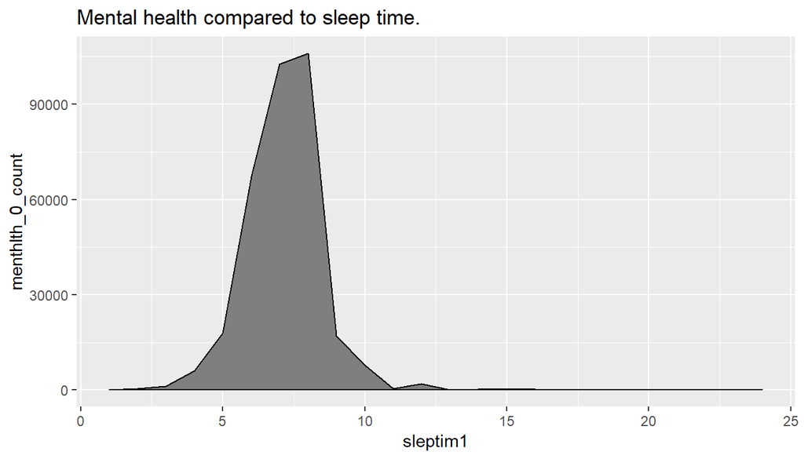

```r
ggplot(data=brfss2013_menthlth_0,aes(x=sleptim1,y=menthlth_0_count))+geom_area(color="Black",fill="gray50")+ggtitle("Mental health compared to sleep time.")
```

Lets look at the same details for people who had the most number of days where their mental health was not good.

```r
brfss2013_menthlth_30 <- brfss2013 %>%
  filter(menthlth!="NA",sleptim1!="NA",menthlth==30) %>%
  group_by(sleptim1) %>%
  summarise(menthlth_30_count=n()) %>%
  arrange(desc(menthlth_30_count))

brfss2013_menthlth_30
```

```
## # A tibble: 23 x 2
##    sleptim1 menthlth_30_count
##       <int>             <int>
##  1        6              6148
##  2        8              4417
##  3        7              3587
##  4        5              3543
##  5        4              2870
##  6       10               966
##  7        9               946
##  8        3               905
##  9       12               528
## 10        2               318
## # ... with 13 more rows
```

We see that the people who have the most mentally disturbing days usually get only 6 hours of sleep on average.

Lets have a look at the graph of this data.

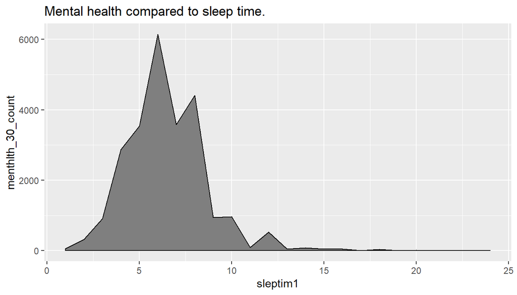

```r
ggplot(data=brfss2013_menthlth_30,aes(x=sleptim1,y=menthlth_30_count))+geom_area(color="Black",fill="gray50")+ggtitle("Mental health compared to sleep time.")
```

```r
brfss2013 %>%
  filter(menthlth!="NA",sleptim1!="NA") %>%
  select(sleptim1) %>%
  summary(sleptim1)
```

```
##     sleptim1
##  Min.   :  0.000
##  1st Qu.:  6.000
##  Median :  7.000
##  Mean   :  7.053
##  3rd Qu.:  8.000
##  Max.   :450.000
```

We can infer from this data that there is an association between number of hours slept and days of mental health not being good. There has to be many other confounding variables that we cannot control for as this is only an observational study. Some variables could also be income level,Employment status, Marital status.

Variables used: “menthlth” and “sleptim1”.

**Research quesion 2:**

Here we can see that the average number of hours per week is 43.03 hours and the median is at 40.

```r
brfss2013 %>%
  filter(scntwrk1!="NA") %>%
  select(scntwrk1) %>%
  summarise(scntwrk1_mean=mean(scntwrk1),scntwrk1_median=median(scntwrk1),scntwrk1_count=n())
```

```
##   scntwrk1_mean scntwrk1_median scntwrk1_count
## 1      43.03659              40          32362
```

```r
brfss2013_scntwrk1<-brfss2013 %>%
  filter(scntwrk1!="NA",X_incomg!="NA") %>%
  select(scntwrk1,X_incomg) %>%
  group_by(X_incomg) %>%
  summarise(scntwrk1_mean1=round(mean(scntwrk1),2))
brfss2013_scntwrk1
```

```
## # A tibble: 5 x 2
##   X_incomg                     scntwrk1_mean1
##   <fct>                                 <dbl>
## 1 Less than $15,000                      35.3
## 2 $15,000 to less than $25,000           38.0
## 3 $25,000 to less than $35,000           41.4
## 4 $35,000 to less than $50,000           43.2
## 5 $50,000 or more                        44.8
```

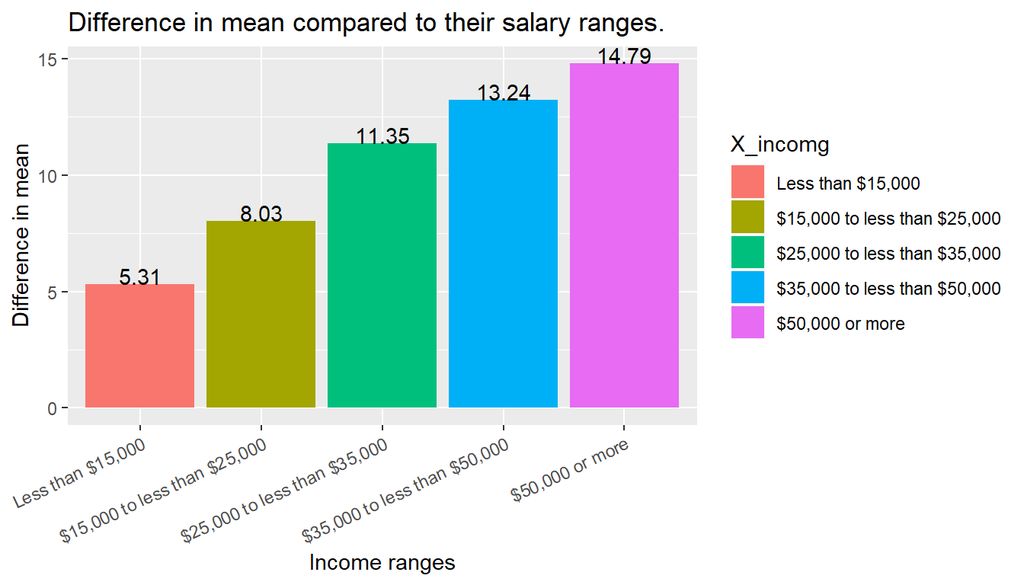

```r
dcd<-30
ggplot(data=brfss2013_scntwrk1,aes(x=X_incomg,y=scntwrk1_mean1-dcd,fill=X_incomg))+geom_col()+theme(axis.text.x = element_text(angle = 25,hjust=1))+ggtitle("Difference in mean compared to their salary ranges.")+xlab("Income ranges")+ylab("Difference in mean")+geom_text(aes(label=c(scntwrk1_mean1[1]-dcd,scntwrk1_mean1[2]-dcd,scntwrk1_mean1[3]-dcd,scntwrk1_mean1[4]-dcd,scntwrk1_mean1[5]-dcd),vjust=c(0,0,0,0,0)))
```

We can cleary see that as the salary increases so does the number of hours.

Lets now compare this to satisfaction with life.

```r
brfss2013_scntwrk_lsatisfy<-brfss2013 %>%
  filter(scntwrk1!="NA",X_incomg!="NA",lsatisfy!="NA") %>%
  select(scntwrk1,X_incomg,lsatisfy) %>%
  group_by(X_incomg,lsatisfy) %>%
  summarise(scntwrk1_mean1=round(mean(scntwrk1),2))
brfss2013_scntwrk_lsatisfy1<-head(brfss2013_scntwrk_lsatisfy,14)
brfss2013_scntwrk_lsatisfy1
```

```
## # A tibble: 14 x 3
## # Groups:   X_incomg [5]
##    X_incomg                     lsatisfy       scntwrk1_mean1
##    <fct>                        <fct>                   <dbl>
##  1 Less than $15,000            Very satisfied           33.8
##  2 Less than $15,000            Satisfied                38.1
##  3 Less than $15,000            Dissatisfied             23.5
##  4 $15,000 to less than $25,000 Very satisfied           37.6
##  5 $15,000 to less than $25,000 Satisfied                35.1
##  6 $15,000 to less than $25,000 Dissatisfied             40
##  7 $25,000 to less than $35,000 Very satisfied           34
##  8 $25,000 to less than $35,000 Satisfied                43.8
##  9 $35,000 to less than $50,000 Very satisfied           45.1
## 10 $35,000 to less than $50,000 Satisfied                47.2
## 11 $35,000 to less than $50,000 Dissatisfied             30
## 12 $50,000 or more              Very satisfied           43.9
## 13 $50,000 or more              Satisfied                47.0
## 14 $50,000 or more              Dissatisfied             42
```

Lets see how this summary looks on a plot

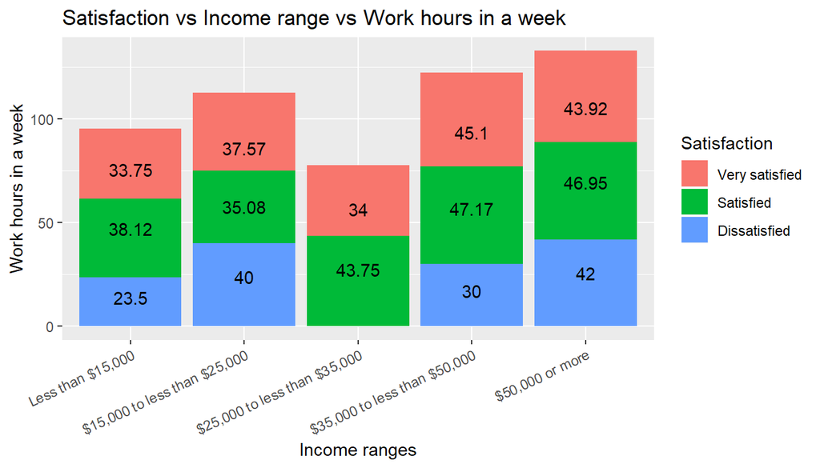

```r
p=ggplot(brfss2013_scntwrk_lsatisfy1,aes(X_incomg,scntwrk1_mean1,fill=lsatisfy))+geom_col()

text_positions<-c(-6,-0.90,2,-7,-3,3,-3,3,-7,-1,2.5,-9,-3,3)

p+theme(axis.text.x = element_text(angle =25,hjust=1))+ggtitle("Satisfaction vs Income range vs Work hours in a week ") +ylab("Work hours in a week") + xlab("Income ranges")+labs(fill = "Satisfaction")+geom_text(aes(label=c(scntwrk1_mean1[1],scntwrk1_mean1[2],scntwrk1_mean1[3],scntwrk1_mean1[4],scntwrk1_mean1[5],scntwrk1_mean1[6],scntwrk1_mean1[7],scntwrk1_mean1[8],scntwrk1_mean1[9],scntwrk1_mean1[10],scntwrk1_mean1[11],scntwrk1_mean1[12],scntwrk1_mean1[13],scntwrk1_mean1[14])), vjust=text_positions)
```

Variables used: “lsatisfy”

“X_incomg”

“scntwrk1”

**Research quesion 3:**

Lets compare and see if height has anything to do with how much a person earns and if there is some sort of co-relation between the two variables.

To compare lets take a sample from our data set.

```r
sample_brfss2013<-brfss2013[sample(nrow(brfss2013),0.05*nrow(brfss2013),replace = F),] %>%
  filter(htin4!="NA",htin4<1000,X_incomg!="NA") %>%
  select(X_incomg,htin4) %>%
  group_by(X_incomg) %>%
  summarise(mean=mean(htin4))
head(sample_brfss2013,10)
```

```
## # A tibble: 5 x 2
##   X_incomg                      mean
##   <fct>                        <dbl>
## 1 Less than $15,000             65.5
## 2 $15,000 to less than $25,000  66.1
## 3 $25,000 to less than $35,000  66.3
## 4 $35,000 to less than $50,000  66.9
## 5 $50,000 or more               67.5
```

I have take a sample size of about 5% of our data set. Removed any “NA” as they might interfere with our statistics.

Lets see how the data looks once plotted against each other.

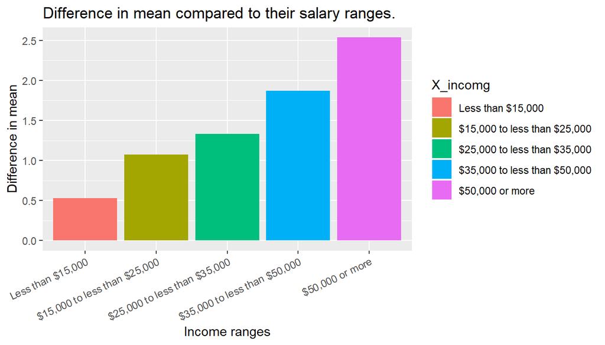

```r
ggplot(data=sample_brfss2013,aes(x=X_incomg,y=mean-65,fill=X_incomg))+geom_col()+theme(axis.text.x = element_text(angle = 25,hjust=1))+ggtitle("Difference in mean compared to their salary ranges.")+xlab("Income ranges")+ylab("Difference in mean")
```

Here we can see that as the salaries increase even the mean of the height increases.

Lets also have a look at the medians of all different categories of the variable X_incomg compared to height.

```r
median_sample_brfss2013<- brfss2013[sample(nrow(brfss2013),0.05*nrow(brfss2013),replace = F),] %>%
  filter(htin4!="NA",htin4<1000,X_incomg!="NA") %>%
  select(X_incomg,htin4) %>%
  group_by(X_incomg,htin4)
```

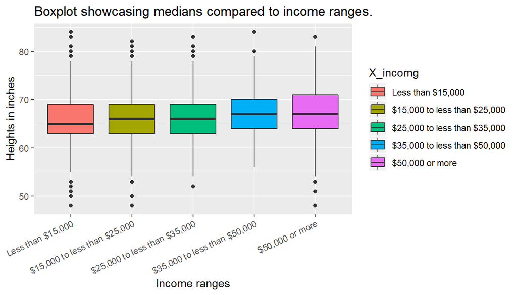

```r
ggplot(median_sample_brfss2013,aes(x=X_incomg,y=htin4,fill=X_incomg)) + geom_boxplot()+theme(axis.text.x = element_text(angle = 25,hjust=1))+ggtitle("Boxplot showcasing medians compared to income ranges.")+xlab("Income ranges")+ylab("Heights in inches")
```

Here we can see that as the salaries increase the medians also have a slow but noticeable increase. The number of outliers also tend to reduce as we go higher on the salary scale. Also even tho the numbers of people in the $50,000 or more category are higher, median being robust doesnt get affected by the population of our sample.

Lets see what the mean of all the heights are.

```r
brfss2013 %>%
  filter(htin4!="NA") %>%
  select(htin4) %>%
  summarise(mean_htin4=mean(htin4))
```

```
##   mean_htin4
## 1   66.68255
```

Now we can see that the average is 66.7 inches. Lets have a look at how incomes vary according to heights using 66.7 inches as a bench mark to distinguish the 2 categories.

```r
heightcategory_brfss2013 <- median_sample_brfss2013 %>%
  mutate(heightcategory=ifelse(htin4>=66.7,"Above 66.7","Below 66.7")) %>%
  filter(X_incomg!="NA") %>%
  group_by(X_incomg,heightcategory) %>%
  summarise(count=n()) %>%
  arrange(desc(count))
heightcategory_brfss2013
```

```
## # A tibble: 10 x 3
## # Groups:   X_incomg [5]
##    X_incomg                     heightcategory count
##    <fct>                        <chr>          <int>
##  1 $50,000 or more              Above 66.7      5104
##  2 $50,000 or more              Below 66.7      3721
##  3 $15,000 to less than $25,000 Below 66.7      2229
##  4 $15,000 to less than $25,000 Above 66.7      1604
##  5 $35,000 to less than $50,000 Above 66.7      1585
##  6 $35,000 to less than $50,000 Below 66.7      1518
##  7 Less than $15,000            Below 66.7      1473
##  8 $25,000 to less than $35,000 Below 66.7      1353
##  9 $25,000 to less than $35,000 Above 66.7      1119
## 10 Less than $15,000            Above 66.7      1000
```

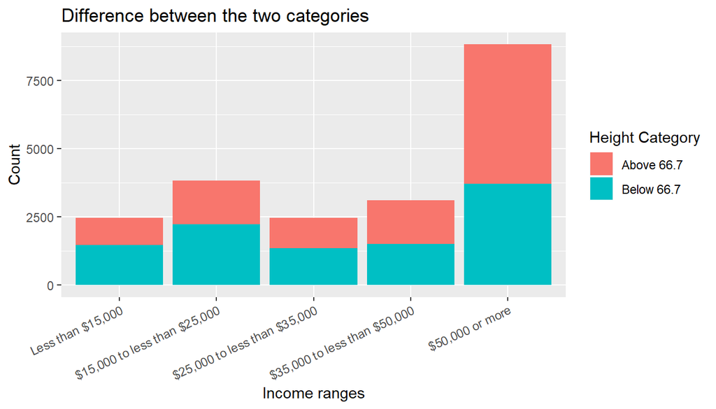

```r
ggplot(heightcategory_brfss2013,aes(X_incomg,count,fill=heightcategory))+geom_col()+theme(axis.text.x = element_text(angle = 25,hjust=1))+ggtitle("Difference between the two categories")+xlab("Income ranges")+ylab("Count")+labs(fill = "Height Category")
```

We can see that a larger percentage of people who are over the average of height of 66.7 are given jobs that pay over $50,000 than compared to the number of people who have a height below 66.7.

Noticing the other counts we see that people who are below the height of 66.7 have more jobs below the $50,000 benchmark. This strengthens our point even more.

We can make an association between the 2 variables htin4 and X_incomg. I have used these two variables for ease of computation and they also give accurate and readable results.

Variables used. “htin4”,“X_incomg” and “heightcategory”.